# Food Inspection: Modeling Risk Assignment using Ordinal Logistic Regression

Final Project Team: Christopher Hein, Yuming Liao, Andrew McCurdy, Nina Randorf, Melanie Tran

3/15/2021

**Project Description** Building an Ordinal Logistic Regression (OLR) model, this project seeks to determine what factors influence risk assignment (Low/Med/High) for restaurants which passed their inspections. This document explores City of Chicago Food Inspections data from July 1, 2018 to February 19, 2021. This script loads data from “cleanedInspection.csv”, a cleaned version of the Food Inspection data.

The raw Chicago Food Inspections data can also be downloaded directly from:  
https://data.cityofchicago.org/Health-Human-Services/Food-Inspections-7-1-2018-Present/qizy-d2wf/data

The food inspection checklist describing inspection focus areas can be viewed at:  
https://www.chicago.gov/city/en/depts/cdph/provdrs/healthy_restaurants/svcs/understand_healthcoderequirementsforfoodestablishments.html

The five main parts of this document include:  
I. Initial Data Exploration  
II. Model Building  
III. Model Testing  
IV. Interpretation & Results  
V. Additional Insight

#### I. INITIAL DATA EXPLORATION

We begin initial data exploration with loading and viewing the “cleanedInspection.csv” data. We can remove the excess index column and any columns which have less than 1 factor as these will causes errors during the model building and testing phase.

Loading the data, we can view all 24 categorical variables in the dataset. “Risk” is the ordinal response variable (clear ordered categories of “Low”, “Med”, and “High”). “Inspection.Date” represents the season of the inspection (Spring, Summer, Fall, Winter). All other categories, such as “Supervision” and “EmployeeHealth” represent different health inspection focus areas; this data represents whether a restaurant passed or incurred a “hit” (violation) of a health code in that category.

Of the 24 independent variables, we can drop “Facility.Type” and “Inspection.Type” due to scoping limitations. While data is available on multiple types of facilities (restaurants, gas stations, schools) and inspections (licensing, re-inspections, complaints), this model and analysis focuses only on Restaurant and Canvass inspections. As the data was already cleaned and filtered for Restaurants and Canvass Inspections, we can drop these two columns as constants. This leaves the dataset with one response and 22 independent variables.

```r
#don't need this line if your file is saved in the same directory folder
#dataPath <- setwd()

#load cleaned data
dta <- read.csv("cleanedInspection.csv")

#inspecting the dta table, we still need to remove a few extra columns
dta$X <- NULL #remove index extra column
dta$Facility.Type <- NULL #this is a constant due to scope limits
dta$Inspection.Type <- NULL #this is a constant due to scope limits

#view head
head(dta)
```

```
##   Risk Inspection.Date Supervision EmployeeHealth HygenicPractices
## 1  Med          Summer           0              0                0
## 2 High          Summer           0              0                0
## 3 High          Summer           0              1                0
## 4 High          Summer           0              0                0
## 5 High          Summer           0              0                0
## 6 High          Summer           0              0                0
##   HandContamination ApprovedSource Contamination TimeTemp ConsumerAdvisory
## 1                 0              0             0        0                0
## 2                 0              0             0        0                0
## 3                 0              0             0        0                0
## 4                 0              0             0        0                0
## 5                 1              0             0        0                0
## 6                 0              0             0        0                0
##   SusceptiblePop AdditiveSafety ApprovedProcedures SafeFood FoodTemperature
```

[output cut: 20 more lines]

With the data loaded, we can now convert data types to factor and specify specific ordering. For instance, “Risk” must be ordered to reflect “Low”, “Med”, and “High. We can order all dependent variables as well (i.e. ”Pass" is better than a “Hit”) except “Inspection.Date” as seasons have no intrinsic order value.

Reference Source: Perceptive Analytics. How to Perform Ordinal Logistic Regression in R. R-bloggers, 18 June 2019, r-bloggers.com/2019/06/how-to-perform-ordinal-logistic-regression-in-r/.

```r
#converting to factor and explicitly defining the ordering levels for all features except Inspection.Date (seasons)

#response
dta$Risk <- factor(dta$Risk, levels = c("Low", "Med", "High"), ordered = T)

#predictors
dta$Inspection.Date <- factor(dta$Inspection.Date, levels = c("Fall", "Winter", "Spring", "Summer"), ordered = F)

dta$Supervision <- factor(dta$Supervision, levels = c("0","1"), ordered = T)
dta$EmployeeHealth <- factor(dta$EmployeeHealth, levels = c("0","1"), ordered = T)
dta$HygenicPractices <- factor(dta$HygenicPractices, levels = c("0","1"), ordered = T)

dta$HandContamination <- factor(dta$HandContamination, levels = c("0","1"), ordered = T)
dta$ApprovedSource <- factor(dta$ApprovedSource, levels = c("0","1"), ordered = T)
dta$Contamination <- factor(dta$Contamination, levels = c("0","1"), ordered = T)

dta$TimeTemp <- factor(dta$TimeTemp, levels = c("0","1"), ordered = T)
dta$ConsumerAdvisory <- factor(dta$ConsumerAdvisory, levels = c("0","1"), ordered = T)
dta$SusceptiblePop <- factor(dta$SusceptiblePop, levels = c("0","1"), ordered = T)

dta$AdditiveSafety <- factor(dta$AdditiveSafety, levels = c("0","1"), ordered = T)
dta$ApprovedProcedures <- factor(dta$ApprovedProcedures, levels = c("0","1"), ordered = T)
dta$SafeFood <- factor(dta$SafeFood, levels = c("0","1"), ordered = T)

dta$FoodTemperature <- factor(dta$FoodTemperature, levels = c("0","1"), ordered = T)
dta$FoodIdentification <- factor(dta$FoodIdentification, levels = c("0","1"), ordered = T)
dta$FoodContamination <- factor(dta$FoodContamination, levels = c("0","1"), ordered = T)

dta$ProperUtensils <- factor(dta$ProperUtensils, levels = c("0","1"), ordered = T)
dta$Equipment <- factor(dta$Equipment, levels = c("0","1"), ordered = T)
dta$PhysicalFacilities <- factor(dta$PhysicalFacilities, levels = c("0","1"), ordered = T)

dta$EmployeeTraining <- factor(dta$EmployeeTraining, levels = c("0","1"), ordered = T)
dta$OrdinanceCompliance <- factor(dta$OrdinanceCompliance, levels = c("0","1"), ordered = T)


#convert "0","1" to "Pass" or "Hit" to make the feature easier to interpret
levels(dta$Supervision)[levels(dta$Supervision)=="0"] <-"Pass"
levels(dta$Supervision)[levels(dta$Supervision)=="1"] <-"Hit"

levels(dta$EmployeeHealth)[levels(dta$EmployeeHealth)=="0"] <-"Pass"
levels(dta$EmployeeHealth)[levels(dta$EmployeeHealth)=="1"] <-"Hit"

levels(dta$HygenicPractices)[levels(dta$HygenicPractices)=="0"] <-"Pass"
levels(dta$HygenicPractices)[levels(dta$HygenicPractices)=="1"] <-"Hit"

levels(dta$HandContamination)[levels(dta$HandContamination)=="0"] <-"Pass"
levels(dta$HandContamination)[levels(dta$HandContamination)=="1"] <-"Hit"

levels(dta$ApprovedSource)[levels(dta$ApprovedSource)=="0"] <-"Pass"
levels(dta$ApprovedSource)[levels(dta$ApprovedSource)=="1"] <-"Hit"

levels(dta$Contamination)[levels(dta$Contamination)=="0"] <-"Pass"
levels(dta$Contamination)[levels(dta$Contamination)=="1"] <-"Hit"

levels(dta$TimeTemp)[levels(dta$TimeTemp)=="0"] <-"Pass"
levels(dta$TimeTemp)[levels(dta$TimeTemp)=="1"] <-"Hit"

levels(dta$ConsumerAdvisory)[levels(dta$ConsumerAdvisory)=="0"] <-"Pass"
levels(dta$ConsumerAdvisory)[levels(dta$ConsumerAdvisory)=="1"] <-"Hit"

levels(dta$SusceptiblePop)[levels(dta$SusceptiblePop)=="0"] <-"Pass"
levels(dta$SusceptiblePop)[levels(dta$SusceptiblePop)=="1"] <-"Hit"

levels(dta$AdditiveSafety)[levels(dta$AdditiveSafety)=="0"] <-"Pass"
levels(dta$AdditiveSafety)[levels(dta$AdditiveSafety)=="1"] <-"Hit"

levels(dta$ApprovedProcedures)[levels(dta$ApprovedProcedures)=="0"] <-"Pass"
levels(dta$ApprovedProcedures)[levels(dta$ApprovedProcedures)=="1"] <-"Hit"

levels(dta$SafeFood)[levels(dta$SafeFood)=="0"] <-"Pass"
levels(dta$SafeFood)[levels(dta$SafeFood)=="1"] <-"Hit"

levels(dta$FoodTemperature)[levels(dta$FoodTemperature)=="0"] <-"Pass"
levels(dta$FoodTemperature)[levels(dta$FoodTemperature)=="1"] <-"Hit"

levels(dta$FoodIdentification)[levels(dta$FoodIdentification)=="0"] <-"Pass"
levels(dta$FoodIdentification)[levels(dta$FoodIdentification)=="1"] <-"Hit"

levels(dta$FoodContamination)[levels(dta$FoodContamination)=="0"] <-"Pass"
levels(dta$FoodContamination)[levels(dta$FoodContamination)=="1"] <-"Hit"

levels(dta$ProperUtensils)[levels(dta$ProperUtensils)=="0"] <-"Pass"
levels(dta$ProperUtensils)[levels(dta$ProperUtensils)=="1"] <-"Hit"

levels(dta$Equipment)[levels(dta$Equipment)=="0"] <-"Pass"
levels(dta$Equipment)[levels(dta$Equipment)=="1"] <-"Hit"

levels(dta$PhysicalFacilities)[levels(dta$PhysicalFacilities)=="0"] <-"Pass"
levels(dta$PhysicalFacilities)[levels(dta$PhysicalFacilities)=="1"] <-"Hit"

levels(dta$EmployeeTraining)[levels(dta$EmployeeTraining)=="0"] <-"Pass"
levels(dta$EmployeeTraining)[levels(dta$EmployeeTraining)=="1"] <-"Hit"

levels(dta$OrdinanceCompliance)[levels(dta$OrdinanceCompliance)=="0"] <-"Pass"
levels(dta$OrdinanceCompliance)[levels(dta$OrdinanceCompliance)=="1"] <-"Hit"
```

Looking at the data summary, we can see a count of all the categorical variables. The ordinal response, Risk, is imbalanced, with approximately 83% High, 16.75% Med, 0.19% Low assignments.

Noting this imbalance, we will have to address a couple points for model building and testing:

1. The Brant test (a test for proportional odds, a required assumption of OLR) can only be applied to factors with more than 1 level. We must remove “SafeFood” and “SusceptiblePop” as these features have no “Hits” (i.e. no recorded restaurant inspection included a violation within those two categories). Trying to maintain as many features as possible, our data now includes 1 response and 20 independent variables.
2. An imbalanced dataset can skew a model during a train-test split. We must inspect which variables can be reasonably included in a train-test split (i.e. consider removing “outlier” variables which only include rare violations). We will also inspect a resampling method to see how different train-test splits affect model performance in the model testing section.

```r
#summarize data
summary(dta)
```

```
##    Risk      Inspection.Date Supervision EmployeeHealth HygenicPractices
##  Low :   5   Fall  :626      Pass:2611   Pass:2598      Pass:2602
##  Med : 438   Winter:907      Hit :   3   Hit :  16      Hit :  12
##  High:2171   Spring:574
##              Summer:507
##  HandContamination ApprovedSource Contamination TimeTemp    ConsumerAdvisory
##  Pass:2292         Pass:2613      Pass:2471     Pass:2600   Pass:2598
##  Hit : 322         Hit :   1      Hit : 143     Hit :  14   Hit :  16
##
##
##  SusceptiblePop AdditiveSafety ApprovedProcedures SafeFood    FoodTemperature
##  Pass:2614      Pass:2605      Pass:2613          Pass:2614   Pass:2454
##  Hit :   0      Hit :   9      Hit :   1          Hit :   0   Hit : 160
##
##
##  FoodIdentification FoodContamination ProperUtensils Equipment
##  Pass:2302          Pass:2060         Pass:2379      Pass:1388
##  Hit : 312          Hit : 554         Hit : 235      Hit :1226
##
##
##  PhysicalFacilities EmployeeTraining OrdinanceCompliance
##  Pass: 553          Pass:2256        Pass:2606
##  Hit :2061          Hit : 358        Hit :   8
##
##
```

```r
#remove categories which had not "Hits" for compatibility with the proportional odds test
dta$SafeFood <- NULL
dta$SusceptiblePop <- NULL
summary(dta)
```

```
##    Risk      Inspection.Date Supervision EmployeeHealth HygenicPractices
##  Low :   5   Fall  :626      Pass:2611   Pass:2598      Pass:2602
##  Med : 438   Winter:907      Hit :   3   Hit :  16      Hit :  12
##  High:2171   Spring:574
##              Summer:507
##  HandContamination ApprovedSource Contamination TimeTemp    ConsumerAdvisory
##  Pass:2292         Pass:2613      Pass:2471     Pass:2600   Pass:2598
##  Hit : 322         Hit :   1      Hit : 143     Hit :  14   Hit :  16
##
##
##  AdditiveSafety ApprovedProcedures FoodTemperature FoodIdentification
##  Pass:2605      Pass:2613          Pass:2454       Pass:2302
##  Hit :   9      Hit :   1          Hit : 160       Hit : 312
##
##
##  FoodContamination ProperUtensils Equipment   PhysicalFacilities
##  Pass:2060         Pass:2379      Pass:1388   Pass: 553
##  Hit : 554         Hit : 235      Hit :1226   Hit :2061
##
##
##  EmployeeTraining OrdinanceCompliance
##  Pass:2256        Pass:2606
##  Hit : 358        Hit :   8
##
##
```

To find outliers and determine which variables could be reasonably included in a train-test split, we can calculate the “hit” percentage of all features. We can consider any variable with less than 5% hits to be an outlier and excluded in this analysis (5% hits = out of 100 inspections, 5 documents documented violations in a specific health category).

Removing these outliers leaves us with a smaller data subset consisting of one response and 10 independent variables.

```r
#get column names of the dataframe which represents the features in the analysis
col_names <- colnames(dta)

#calculate percentage hits (proportion of times an inspection recorded a "hit")
percentage_hits <- c()
for (i in col_names){
  percentage_hits<- c(percentage_hits, print(as.numeric(table(dta[i])[2])/2614))
}
```

```
## [1] 0.1675593
## [1] 0.3469778
## [1] 0.001147666
## [1] 0.006120888
## [1] 0.004590666
## [1] 0.1231829
## [1] 0.0003825555
## [1] 0.05470543
## [1] 0.005355777
## [1] 0.006120888
## [1] 0.003442999
## [1] 0.0003825555
## [1] 0.06120888
## [1] 0.1193573
## [1] 0.2119357
## [1] 0.08990054
## [1] 0.469013
## [1] 0.7884468
## [1] 0.1369549
## [1] 0.003060444
```

```r
#create percentage hit matrix
p_h <- as.data.frame(percentage_hits, col_names)
p_h$index <-(row.names(p_h))

#compute percentage of hits per variable, if it's over 5% then add to a passing column (cpass)
cpass <- c()
for (i in seq(1,length(p_h$percentage_hits))){
  #large enough sample size to include variable (at least 5%)
  if(p_h$percentage_hits[i] >= 0.05){
    cpass <- c(cpass, p_h$index[i])
  }
}

#we have 11 variables which have at least 5% of their data has health checklist violation hits, one is the response, so we really have 10 explanatory variables
length(cpass)
```

```
## [1] 11
```

```r
#the 10 explanatory variables of interest
cpass
```

```
##  [1] "Risk"               "Inspection.Date"    "HandContamination"
##  [4] "Contamination"      "FoodTemperature"    "FoodIdentification"
##  [7] "FoodContamination"  "ProperUtensils"     "Equipment"
## [10] "PhysicalFacilities" "EmployeeTraining"
```

```r
#create a dta subset which will be used for analysis and model building
dta_mini <- dta[cpass]
head(dta_mini)
```

```
##   Risk Inspection.Date HandContamination Contamination FoodTemperature
## 1  Med          Summer              Pass          Pass            Pass
## 2 High          Summer              Pass          Pass            Pass
## 3 High          Summer              Pass          Pass            Pass
## 4 High          Summer              Pass          Pass            Pass
## 5 High          Summer               Hit          Pass            Pass
## 6 High          Summer              Pass          Pass            Pass
##   FoodIdentification FoodContamination ProperUtensils Equipment
## 1               Pass              Pass           Pass      Pass
## 2               Pass              Pass           Pass       Hit
## 3               Pass              Pass           Pass       Hit
## 4               Pass              Pass           Pass      Pass
## 5               Pass              Pass           Pass      Pass
## 6               Pass              Pass           Pass      Pass
##   PhysicalFacilities EmployeeTraining
## 1               Pass              Hit
## 2               Pass              Hit
## 3                Hit              Hit
## 4                Hit             Pass
## 5               Pass             Pass
## 6                Hit             Pass
```

As part of the initial data exploration, we can inspect the frequency tables of the remaining 10 independent (explanatory) variables.

```r
#frequency tables and jitter pots (jitter plots are the visual representation of frequency tables)

#Inspection.Date
table(dta_mini$Risk, dta$Inspection.Date)
```

```
##
##        Fall Winter Spring Summer
##   Low     2      0      0      3
##   Med    93     99    124    122
##   High  531    808    450    382
```

```r
#Hand Contamination
table(dta$Risk, dta$HandContamination)
```

```
##
##        Pass  Hit
##   Low     5    0
##   Med   399   39
##   High 1888  283
```

```r
#Contamination
table(dta$Risk, dta$Contamination)
```

```
##
##        Pass  Hit
##   Low     5    0
##   Med   418   20
##   High 2048  123
```

```r
#Food Temperature
table(dta$Risk, dta$FoodTemperature)
```

```
##
##        Pass  Hit
##   Low     4    1
##   Med   399   39
##   High 2051  120
```

```r
#Identification
table(dta$Risk, dta$FoodIdentification)
```

```
##
##        Pass  Hit
##   Low     5    0
##   Med   400   38
##   High 1897  274
```

```r
#FoodContamination
table(dta$Risk, dta$FoodContamination)
```

```
##
##        Pass  Hit
##   Low     4    1
##   Med   354   84
##   High 1702  469
```

```r
#ProperUtensils
table(dta$Risk, dta$ProperUtensils)
```

```
##
##        Pass  Hit
##   Low     5    0
##   Med   416   22
##   High 1958  213
```

```r
#Equipment
table(dta$Risk, dta$Equipment)
```

```
##
##        Pass  Hit
##   Low     2    3
##   Med   246  192
##   High 1140 1031
```

```r
#Physical Facilities
table(dta$Risk, dta$PhysicalFacilities)
```

```
##
##        Pass  Hit
##   Low     1    4
##   Med    89  349
##   High  463 1708
```

```r
#Employee Training
table(dta$Risk, dta$EmployeeTraining)
```

```
##
##        Pass  Hit
##   Low     5    0
##   Med   411   27
##   High 1840  331
```

Jitter plots are the visual representation of the frequency tables.

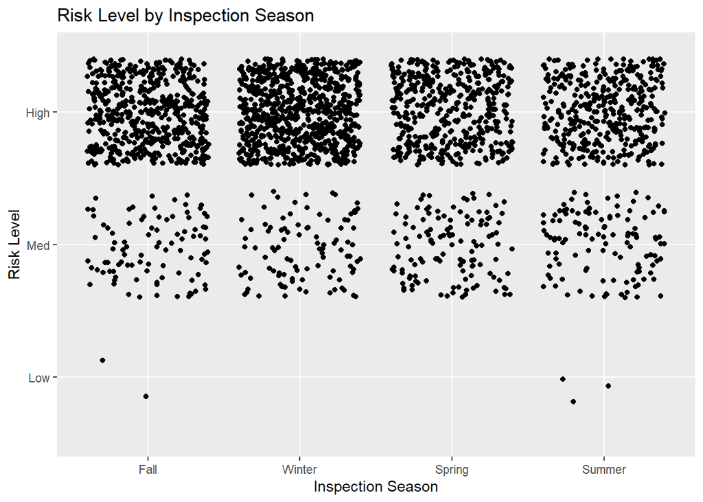

```r
#Inspection.Date
qplot(Inspection.Date, Risk, data=dta, geom="jitter",main="Risk Level by Inspection Season",xlab="Inspection Season", ylab="Risk Level")
```

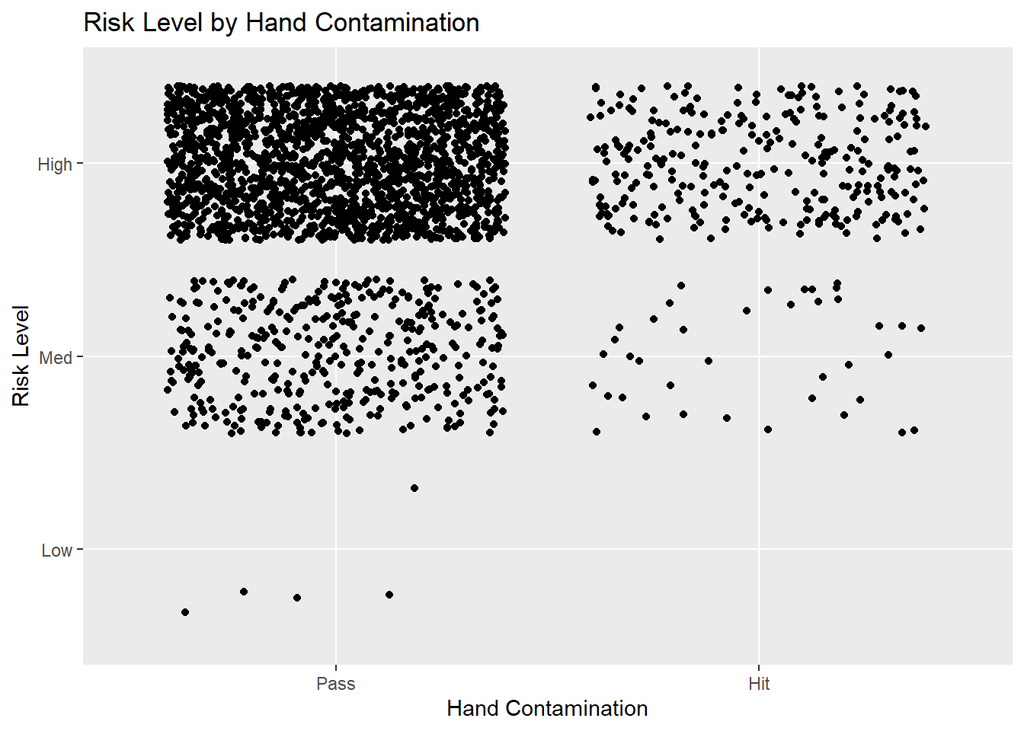

```r
#Hand Contamination
qplot(factor(HandContamination), Risk, data=dta, geom="jitter", main="Risk Level by Hand Contamination",xlab="Hand Contamination", ylab="Risk Level")
```

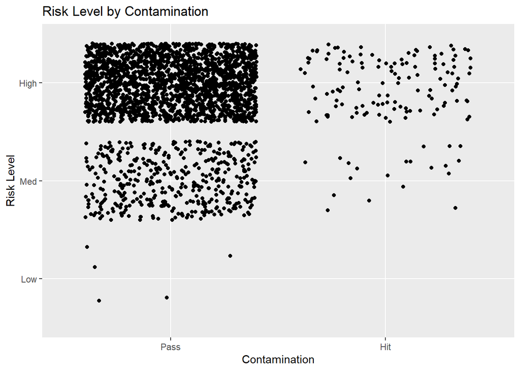

```r
#Contamination
qplot(factor(Contamination), Risk, data=dta, geom="jitter", main="Risk Level by Contamination",xlab="Contamination", ylab="Risk Level")
```

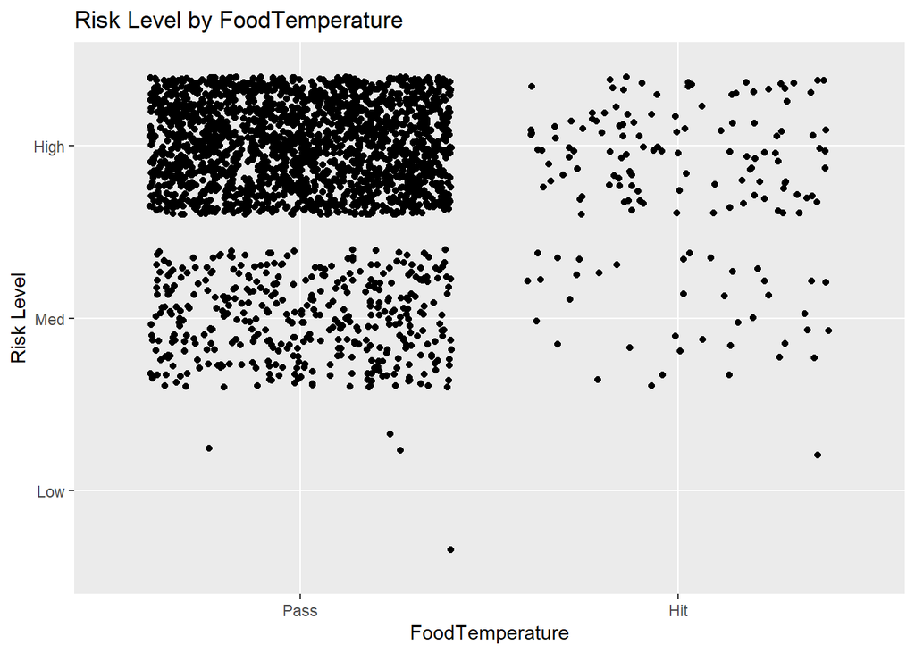

```r
#Food Temperature
qplot(factor(FoodTemperature), Risk, data=dta, geom="jitter", main="Risk Level by FoodTemperature",xlab="FoodTemperature", ylab="Risk Level")
```

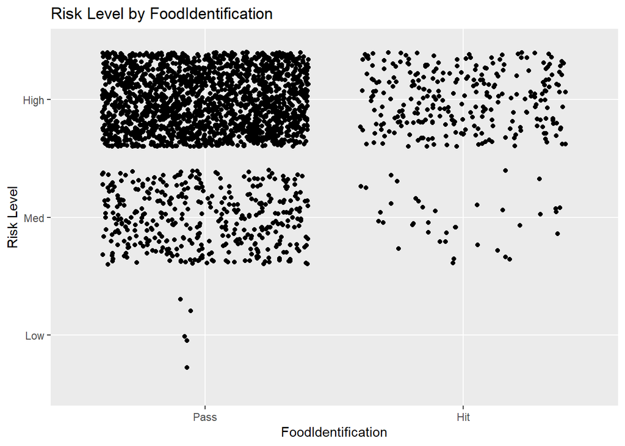

```r
#Identification
qplot(factor(FoodIdentification), Risk, data=dta, geom="jitter", main="Risk Level by FoodIdentification",xlab="FoodIdentification", ylab="Risk Level")
```

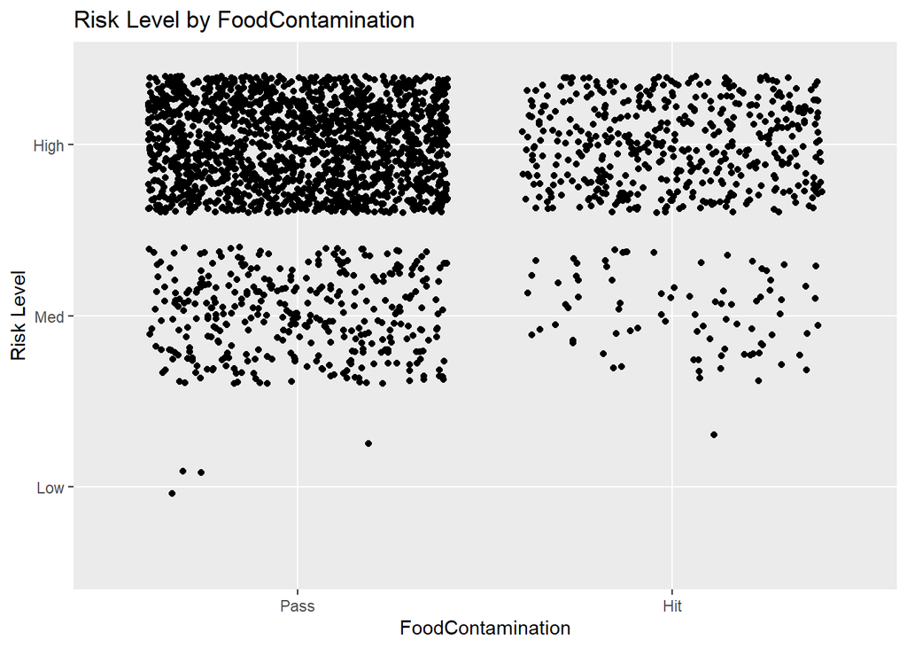

```r
#FoodContamination
qplot(factor(FoodContamination), Risk, data=dta, geom="jitter", main="Risk Level by FoodContamination",xlab="FoodContamination", ylab="Risk Level")
```

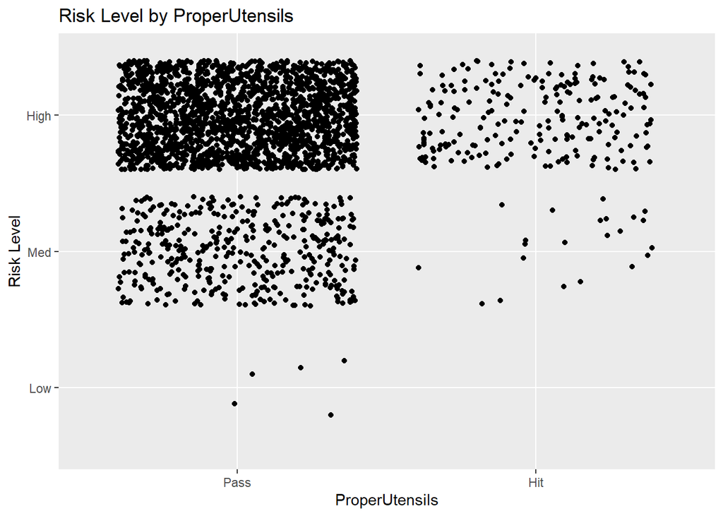

```r
#ProperUtensils
qplot(factor(ProperUtensils), Risk, data=dta, geom="jitter", main="Risk Level by ProperUtensils",xlab="ProperUtensils", ylab="Risk Level")
```

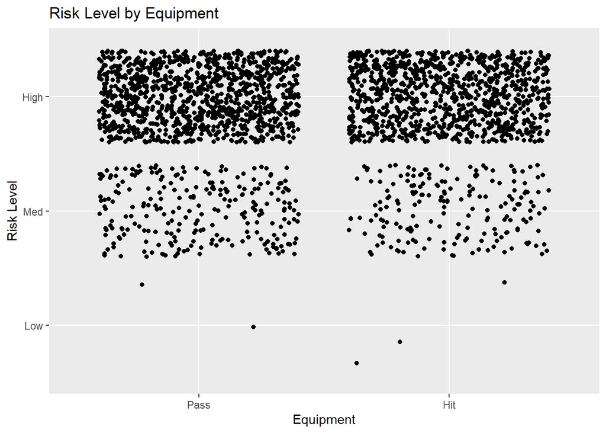

```r
#Equipment
qplot(factor(Equipment), Risk, data=dta, geom="jitter", main="Risk Level by Equipment",xlab="Equipment", ylab="Risk Level")
```

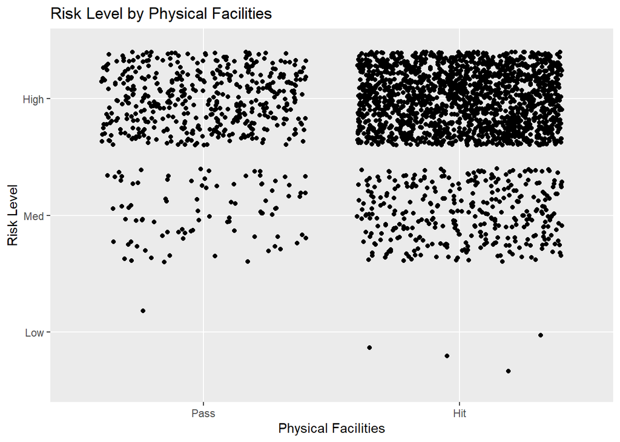

```r
#Physical Facilities
qplot(factor(PhysicalFacilities), Risk, data=dta, geom="jitter", main="Risk Level by Physical Facilities",xlab="Physical Facilities", ylab="Risk Level")
```

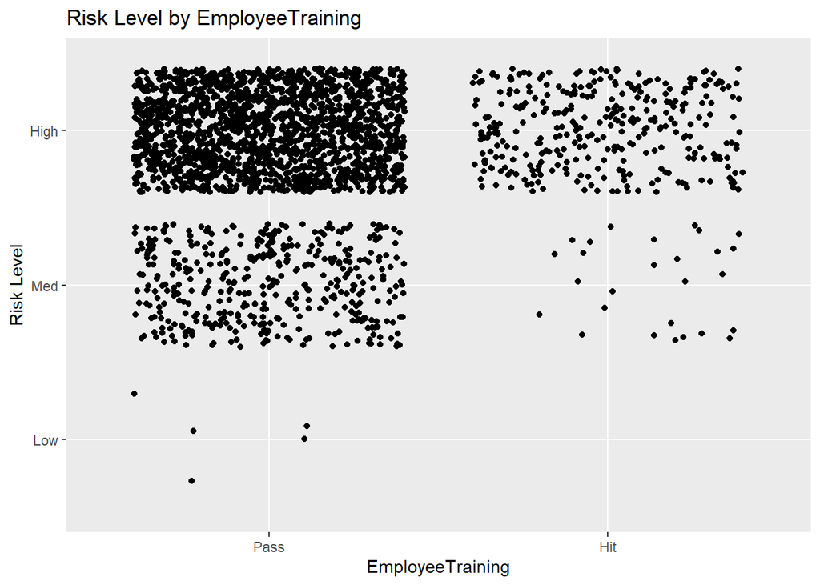

```r
#Employee Training
qplot(factor(EmployeeTraining), Risk, data=dta, geom="jitter", main="Risk Level by EmployeeTraining",xlab="EmployeeTraining", ylab="Risk Level")
```

We can even visualize the frequency plots by season as part of our continued initial data exploration.

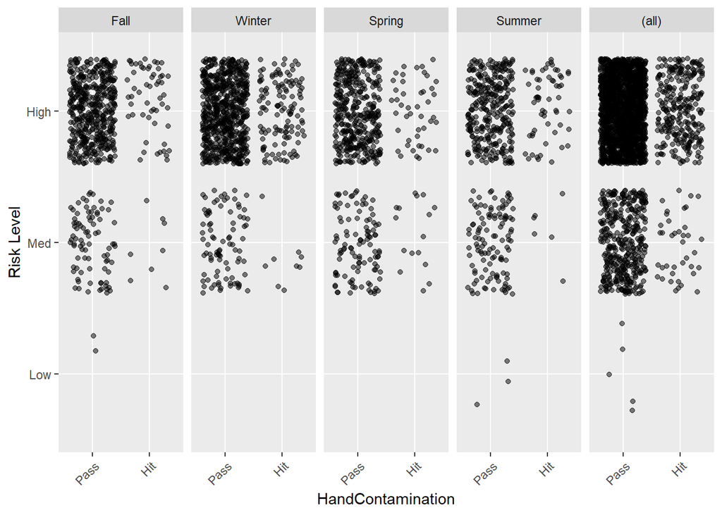

```r
# HandContamination & Inspection.Date
ggplot(dta_mini, aes(x = factor(HandContamination), y = factor(Risk)), xlab = "HandContamination", ylab = "Risk Levels") +
  xlab("HandContamination") + ylab("Risk Level") +
  geom_jitter(alpha = .5) +
  facet_grid(~ Inspection.Date, margins = TRUE) +
  theme(axis.text.x = element_text(angle = 45, hjust = 1, vjust = 1))
```

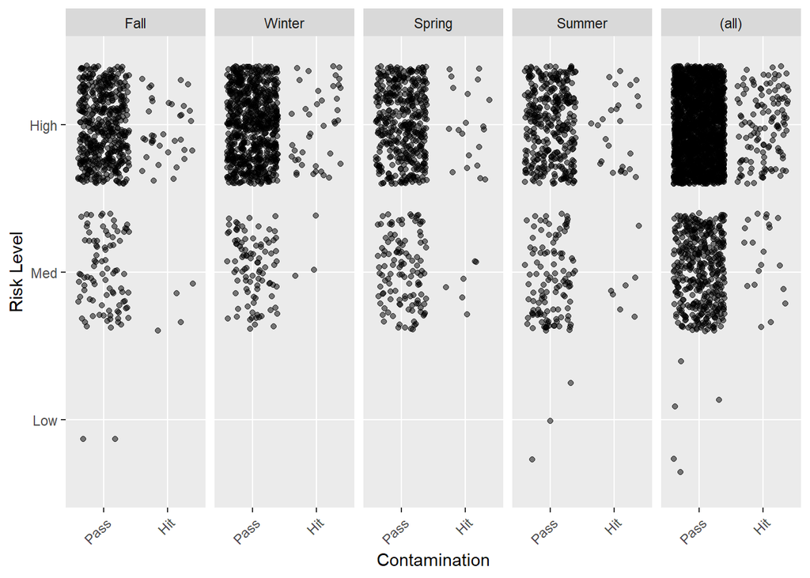

```r
# Contamination & Inspection.Date
ggplot(dta_mini, aes(x = factor(Contamination), y = factor(Risk)), xlab = "Contamination", ylab = "Risk Levels") +
  xlab("Contamination") + ylab("Risk Level") +
  geom_jitter(alpha = .5) +
  facet_grid(~ Inspection.Date, margins = TRUE) +
  theme(axis.text.x = element_text(angle = 45, hjust = 1, vjust = 1))
```

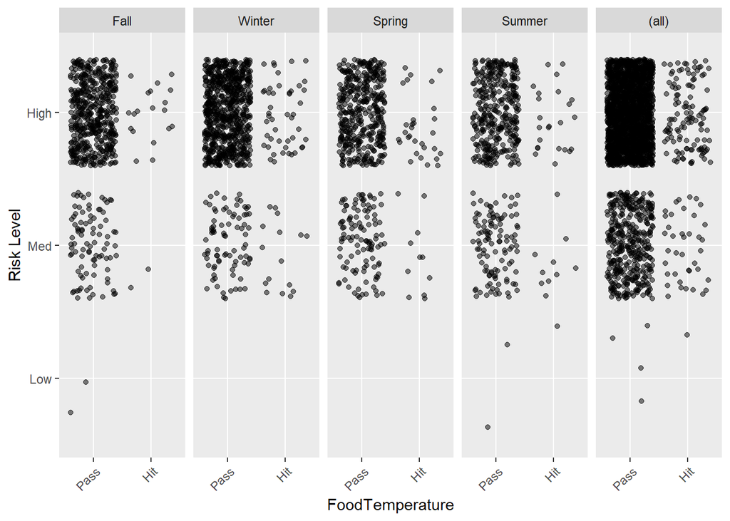

```r
# FoodTemperature & Inspection.Date
ggplot(dta_mini, aes(x = factor(FoodTemperature), y = factor(Risk)), xlab = "FoodTemperature", ylab = "Risk Levels") +
  xlab("FoodTemperature") + ylab("Risk Level") +
  geom_jitter(alpha = .5) +
  facet_grid(~ Inspection.Date, margins = TRUE) +
  theme(axis.text.x = element_text(angle = 45, hjust = 1, vjust = 1))
```

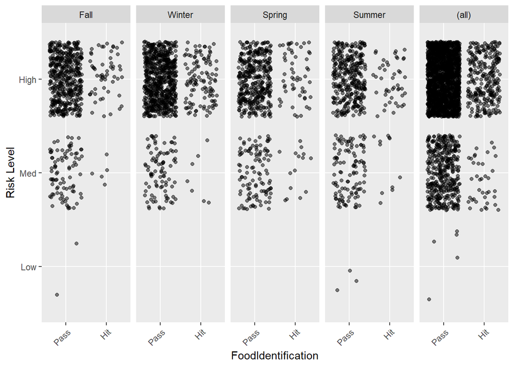

```r
# FoodIdentification & Inspection.Date
ggplot(dta_mini, aes(x = factor(FoodIdentification), y = factor(Risk)), xlab = "FoodIdentification", ylab = "Risk Levels") +
  xlab("FoodIdentification") + ylab("Risk Level") +
  geom_jitter(alpha = .5) +
  facet_grid(~ Inspection.Date, margins = TRUE) +
  theme(axis.text.x = element_text(angle = 45, hjust = 1, vjust = 1))
```

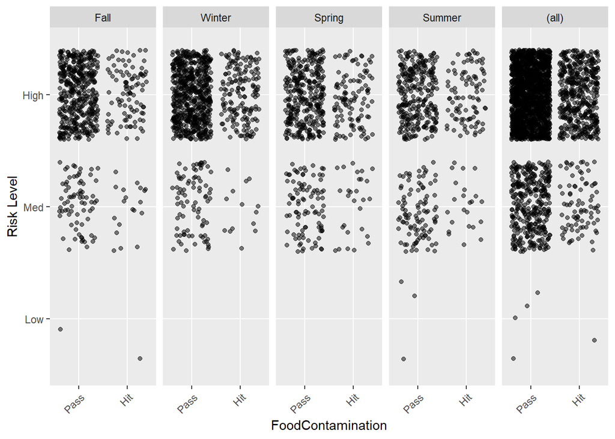

```r
# FoodContamination & Inspection.Date
ggplot(dta_mini, aes(x = factor(FoodContamination), y = factor(Risk)), xlab = "FoodContamination", ylab = "Risk Levels") +
  xlab("FoodContamination") + ylab("Risk Level") +
  geom_jitter(alpha = .5) +
  facet_grid(~ Inspection.Date, margins = TRUE) +
  theme(axis.text.x = element_text(angle = 45, hjust = 1, vjust = 1))
```

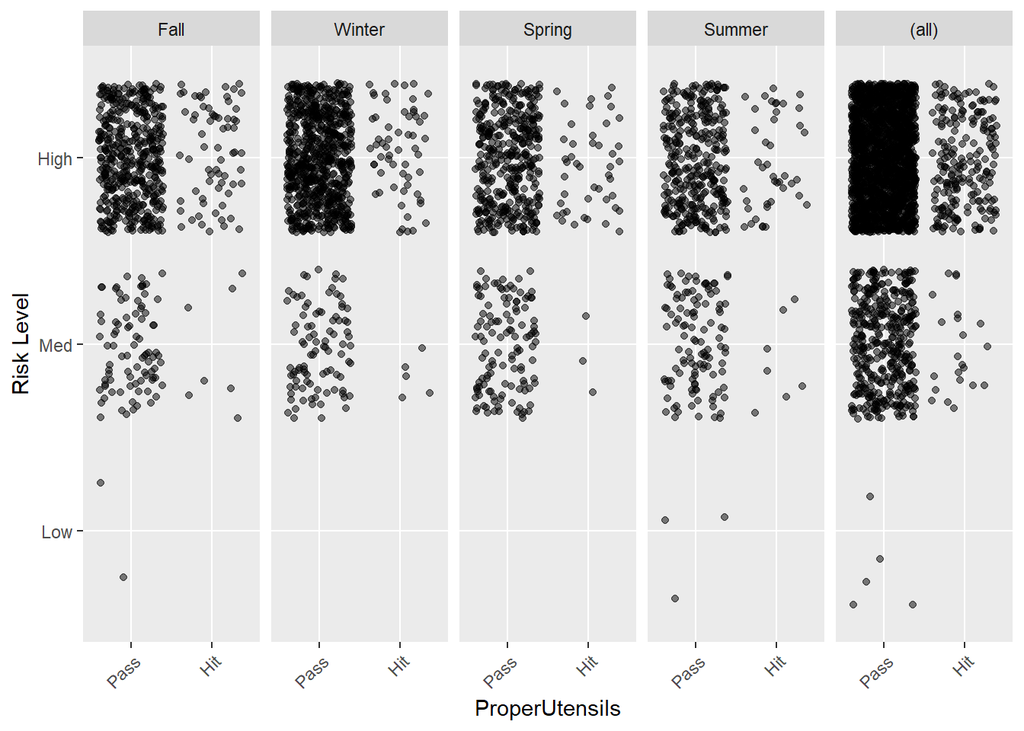

```r
#ProperUtensils & Inspection.Date
ggplot(dta_mini, aes(x = factor(ProperUtensils), y = factor(Risk)), xlab = "ProperUtensils", ylab = "Risk Levels") +
  xlab("ProperUtensils") + ylab("Risk Level") +
  geom_jitter(alpha = .5) +
  facet_grid(~ Inspection.Date, margins = TRUE) +
  theme(axis.text.x = element_text(angle = 45, hjust = 1, vjust = 1))
```

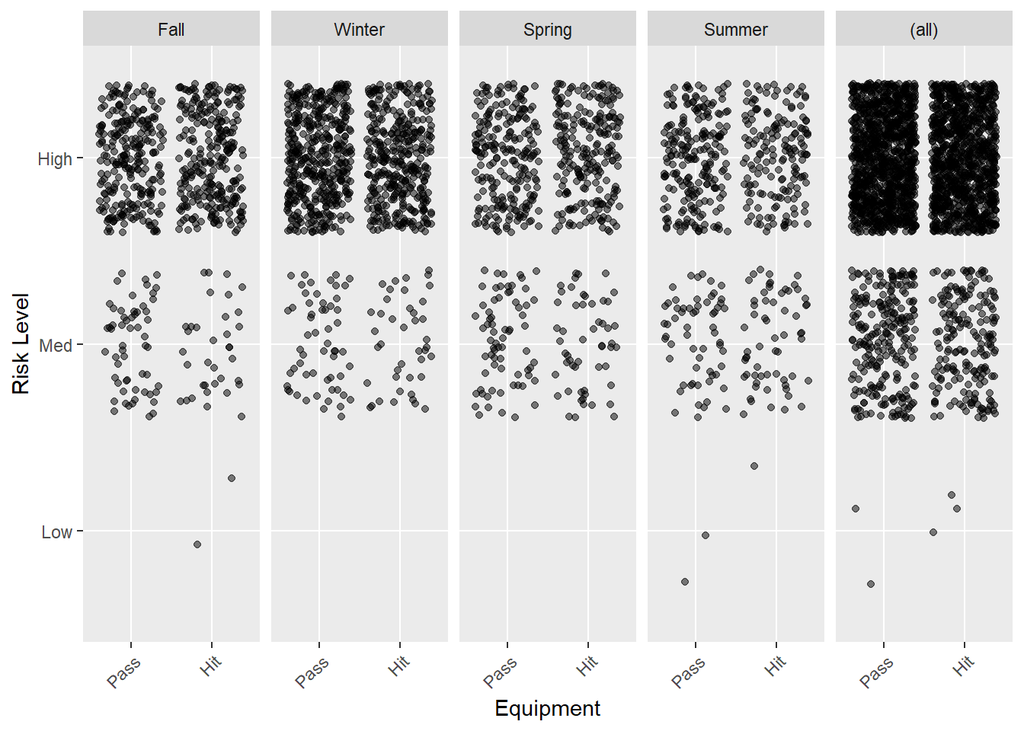

```r
# Equipment & Inspection.Date
ggplot(dta_mini, aes(x = factor(Equipment), y = factor(Risk)), xlab = "Equipment", ylab = "Risk Levels") +
  xlab("Equipment") + ylab("Risk Level") +
  geom_jitter(alpha = .5) +
  facet_grid(~ Inspection.Date, margins = TRUE) +
  theme(axis.text.x = element_text(angle = 45, hjust = 1, vjust = 1))
```

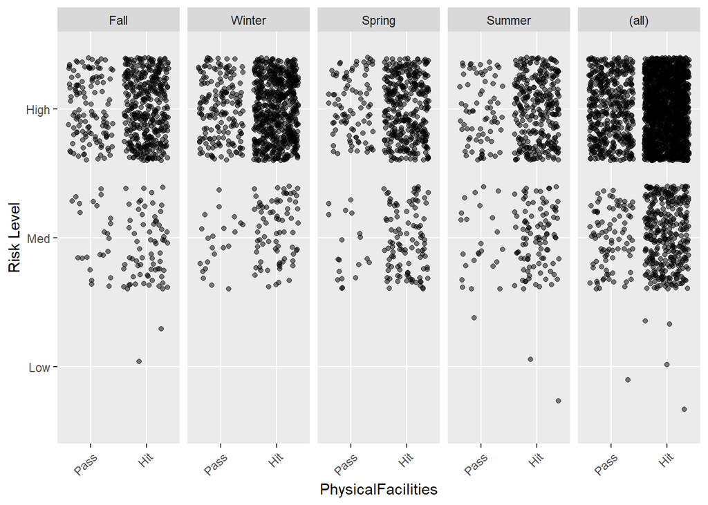

```r
# PhysicalFacilities & Inspection.Date
ggplot(dta_mini, aes(x = factor(PhysicalFacilities), y = factor(Risk)), xlab = "PhysicalFacilities", ylab = "Risk Levels") +
  xlab("PhysicalFacilities") + ylab("Risk Level") +
  geom_jitter(alpha = .5) +
  facet_grid(~ Inspection.Date, margins = TRUE) +
  theme(axis.text.x = element_text(angle = 45, hjust = 1, vjust = 1))
```

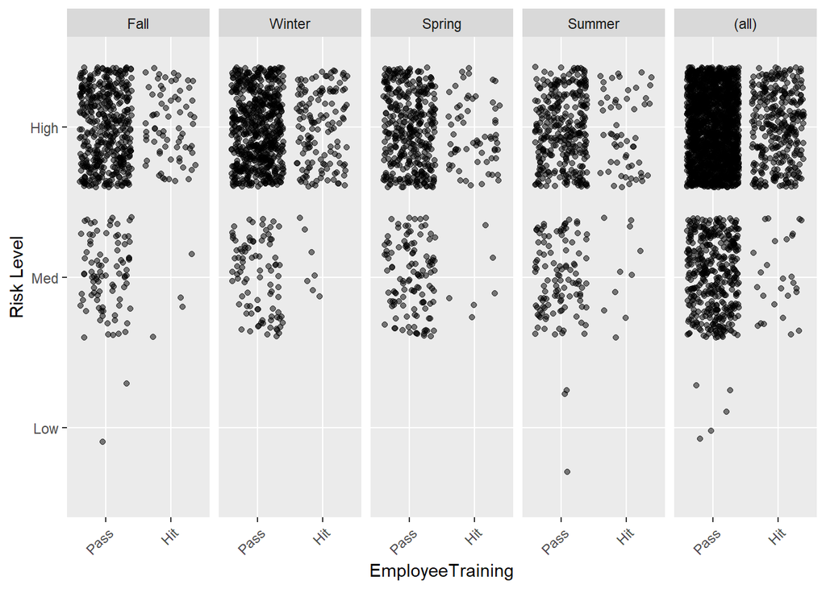

```r
# EmployeeTraining & Inspection.Date
ggplot(dta_mini, aes(x = factor(EmployeeTraining), y = factor(Risk)), xlab = "EmployeeTraining", ylab = "Risk Levels") +
  xlab("EmployeeTraining") + ylab("Risk Level") +
  geom_jitter(alpha = .5) +
  facet_grid(~ Inspection.Date, margins = TRUE) +
  theme(axis.text.x = element_text(angle = 45, hjust = 1, vjust = 1))
```